# Part I - Loan Data

## Univariate Exploration

> In this section, investigate distributions of individual variables. If you see unusual points or outliers, take a deeper look to clean things up and prepare yourself to look at relationships between variables.

### Question 1: What is the distribution of loan statuses in the dataset?

### Visualization 1: Bar Chart of Loan Status Distribution

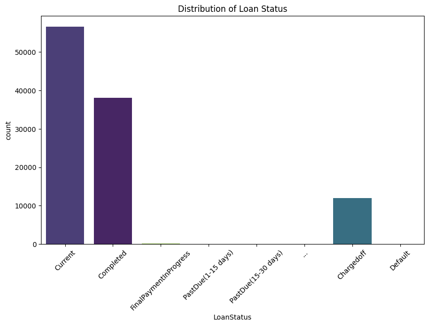

```python
# Order of LoanStatus - [Current, Completed, FinalPaymentProgress, PastDue(1-15 days), PastDue(15-30 days), ..., Chargedoff, Default]
loan_status_order = ['Current', 'Completed', 'FinalPaymentInProgress', 'PastDue(1-15 days)', 'PastDue(15-30 days)', '...', 'Chargedoff', 'Default']

# Loan Status count plot
create_count_plot(prosper_loan_data, 'LoanStatus', 'LoanStatus', 'viridis', 'Distribution of Loan Status', x_rotation=45, order=loan_status_order)
```

### Observations:

- The visualization provides an overview of the distribution of different loan statuses.
- We can observe the frequency of each loan status category, such as "Completed," "Current," and others. "Current" is the most frequent status of over 50,000 records, followed closely by "Completed" of just under 40,000 records. The remaining statuses are under 20,000 records.

### Question 2: What is the distribution of Borrower APR?

### Visualization 2: Histogram of Borrower APR

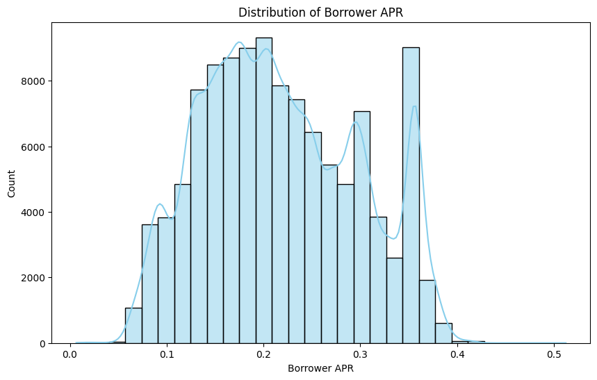

```python
# Plotting the distribution of Borrower APR
plt.figure(figsize=(10, 6))  # Set the figure size
sb.histplot(prosper_loan_data['BorrowerAPR'], bins=30, kde=True, color='skyblue')  # Create a histogram
plt.title('Distribution of Borrower APR')  # Set the title
plt.xlabel('Borrower APR')  # Label the x-axis
plt.show()  # Display the plot
```

### Observations:

- The histogram shows the distribution of Borrower APR.
- It helps identify the common range of APR values and whether there are any outliers.We can see outliers at below 0.1 and above 0.4 Borrower APR.

### Question 3: How are loans distributed across different credit grades?

### Visualization 3: Countplot of Credit Grades

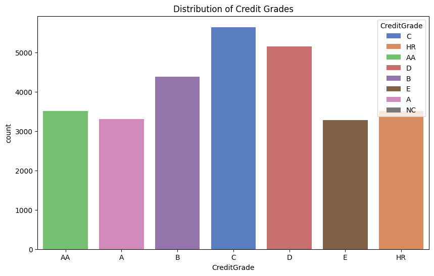

```python
# Order of CreditGrade categories
credit_grade_order = ['AA', 'A', 'B', 'C', 'D', 'E', 'HR']

# Credit Grade count plot
create_count_plot(prosper_loan_data, 'CreditGrade', 'CreditGrade', 'muted', 'Distribution of Credit Grades', order=credit_grade_order)
```

### Observations:

- This visualization provides insights into the distribution of loans across different credit grades.
- It helps understand the prevalence of each credit grade in the dataset. We can see credit grade C is the most prevelant at over 5,000 records with credit grade NC at the lowest prevelance of under 1,000 records.

### Question 4: What is the distribution of loan terms?

### Visualization 4: Bar Chart of Loan Terms

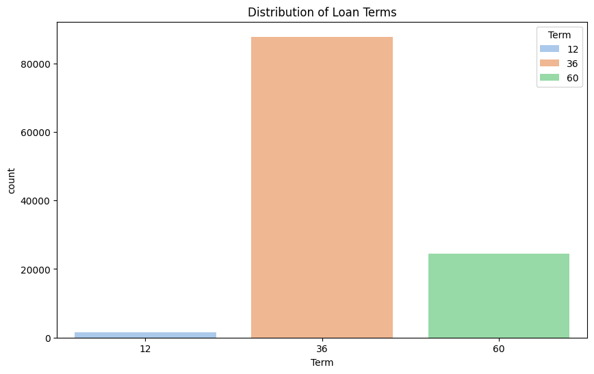

```python
# Loan Term count plot
create_count_plot(prosper_loan_data, 'Term', 'Term', 'pastel', 'Distribution of Loan Terms')
```

### Observations:

- The bar chart displays the distribution of loans based on their terms (e.g., 36 months).
- It provides an overview of the frequency of each term in the dataset. A loan term of 36 months is the most frequent of over 80,000 records. A loan term of 12 months is the lowest frequent of under 10,000 records.